# Exploring the BRFSS data

## Setup

### Load packages

```r
library(ggplot2)
library(dplyr)
```

### Load data

Make sure your data and R Markdown files are in the same directory. When loaded your data file will be called `brfss2013`. Delete this note when before you submit your work.

```r
load("brfss2013.RData")
```

## Part 1: Data

The Behavioral Risk Factor Surveillance System (BRFSS) is a collaborative project between all of the states in the United States (US) and participating US territories and the Centers for Disease Control and Prevention (CDC). The BRFSS is administered and supported by CDC’s Population Health Surveillance Branch, under the Division of Population Health at the National Center for Chronic Disease Prevention and Health Promotion.

BRFSS is an ongoing surveillance system designed to measure behavioral risk factors for the non-institutionalized adult population (18 years of age and older) residing in the US. The BRFSS was initiated in 1984, with 15 states collecting surveillance data on risk behaviors through monthly telephone interviews.

Over time, the number of states participating in the survey increased; by 2001, 50 states, the District of Columbia, Puerto Rico, Guam, and the US Virgin Islands were participating in the BRFSS. Today, all 50 states, the District of Columbia, Puerto Rico, and Guam collect data annually and American Samoa, Federated States of Micronesia, and Palau collect survey data over a limited point- in-time (usually one to three months). In this document, the term “state” is used to refer to all areas participating in BRFSS, including the District of Columbia, Guam, and the Commonwealth of Puerto Rico.

The BRFSS objective is to collect uniform, state-specific data on preventive health practices and risk behaviors that are linked to chronic diseases, injuries, and preventable infectious diseases that affect the adult population. Factors assessed by the BRFSS in 2013 include tobacco use, HIV/AIDS knowledge and prevention, exercise, immunization, health status, healthy days - health-related quality of life, health care access, inadequate sleep, hypertension awareness, cholesterol awareness, chronic health conditions, alcohol consumption, fruits and vegetables consumption, arthritis burden, and seatbelt use. Since 2011, BRFSS conducts both landline telephone- and cellular telephone-based surveys. In conducting the BRFSS landline telephone survey, interviewers collect data from a randomly selected adult in a household. In conducting the cellular telephone version of the BRFSS questionnaire, interviewers collect data from an adult who participates by using a cellular telephone and resides in a private residence or college housing.

Health characteristics estimated from the BRFSS pertain to the non-institutionalized adult population, aged 18 years or older, who reside in the US. In 2013, additional question sets were included as optional modules to provide a measure for several childhood health and wellness indicators, including asthma prevalence for people aged 17 years or younger.

## Part 2: Research questions

**Research quesion 1:** Analysis from main survey - Section 2 - Healthy Days Health-Related Quality of Life

Variables will be used are:

```
physhlth: Number Of Days Physical Health Not Good
menthlth: Number Of Days Mental Health Not Good
poorhlth: Poor Physical Or Mental Health
```

My 1st research question is:

how health conditions are distributed.

**Research quesion 2:** Second, I would like to see if there exists any relation between how many hours one sleeps and certain health conditions such as Heart Attack, Depressive Disorder etc.

Variables will be used are:

```
sleptim1: How Much Time Do You Sleep
cvdinfr4: Ever Diagnosed With Heart Attack
addepev2: Ever Told You Had A Depressive Disorder
```

What I am going to do is:

Will run an initial correlation analysis among these variables.

**Research quesion 3:**

Third, I would like to see if health condition such as Heart Attack can be predicted using sleep time, Cholesterol, blood pressure etc.

Variables I am using here are:

```
cvdinfr4: Ever Diagnosed With Heart Attack
bloodcho: Ever Had Blood Cholesterol Checked
cholchk: How Long Since Cholesterol Checked
toldhi2: Ever Told Blood Cholesterol High
bphigh4: Ever Told Blood Pressure High
sleptim1: How Much Time Do You Sleep
```

What I will be doing is:

Run a basic generalized linear regression analysis among these variables.

## Part 3: Exploratory data analysis

NOTE: Insert code chunks as needed by clicking on the “Insert a new code chunk” button (green button with orange arrow) above. Make sure that your code is visible in the project you submit. Delete this note when before you submit your work.

**Research quesion 1:**

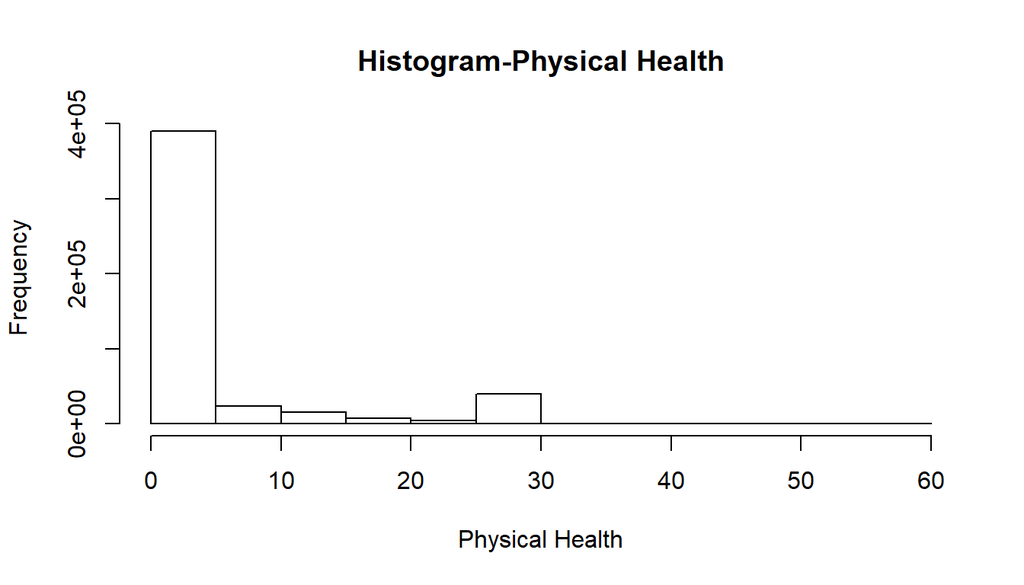

```r
# op <- par(mfrow = c(2, 2))
hist(brfss2013$physhlth, main="Histogram-Physical Health", xlab="Physical Health")
```

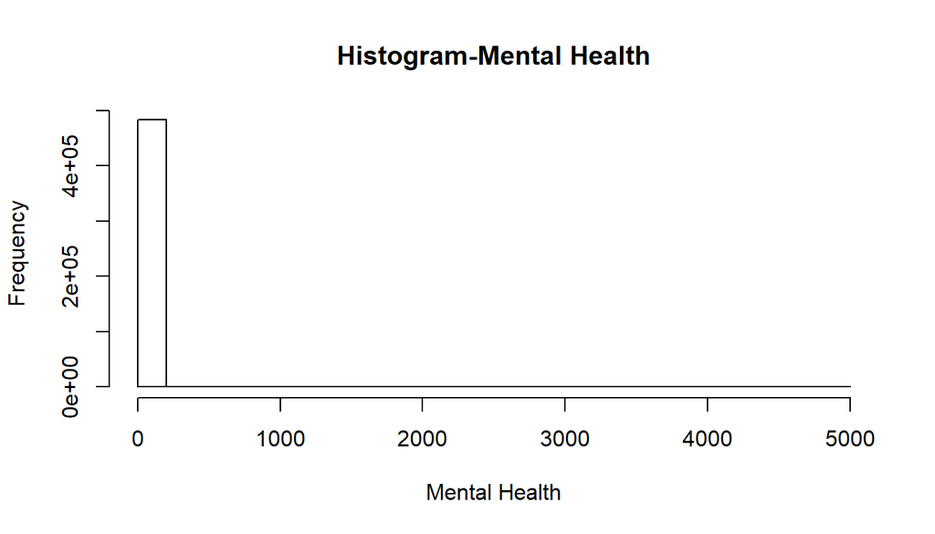

```r
hist(brfss2013$menthlth, main="Histogram-Mental Health", xlab="Mental Health")
```

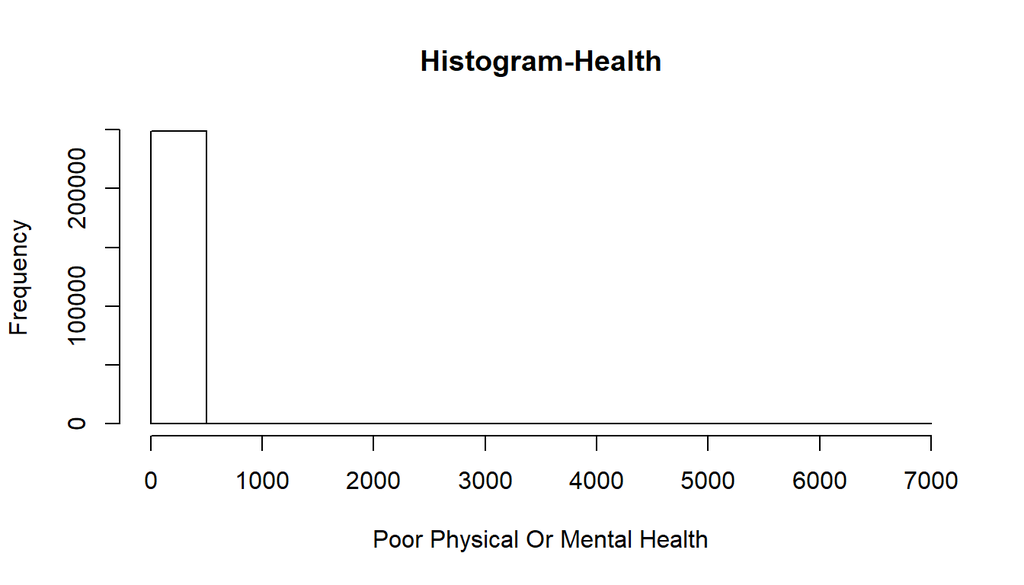

```r
hist(brfss2013$poorhlth, main="Histogram-Health", xlab="Poor Physical Or Mental Health")
```

```r
# par(op)
```

**Research quesion 2:**

```r
# Create a subset of data
vars <- names(brfss2013) %in% c("sleptim1", "cvdinfr4", "addepev2")
subdata <- brfss2013[vars]
# make a backup
subdata1 <- subdata
# conver factor levels into numeric levels
subdata1$addepev2 <- ifelse(subdata$addepev2=="Yes", 1, 0)
subdata1$cvdinfr4 <- ifelse(subdata$cvdinfr4=="Yes", 1, 0)
# remove rows containing NAs
library(Hmisc)
```

```r
subdata1 <- na.delete(subdata1)
# find correlation
cor(subdata1)
```

```
##               sleptim1     cvdinfr4    addepev2
## sleptim1  1.0000000000 0.0002048415 -0.05743056
## cvdinfr4  0.0002048415 1.0000000000  0.05267562
## addepev2 -0.0574305638 0.0526756160  1.00000000
```

Plotting correlations

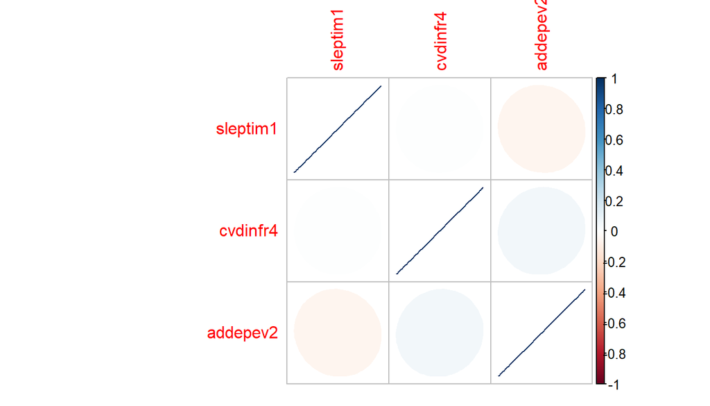

```r
library(corrplot)
M <- cor(subdata1)
corrplot(M, method="ellipse")
```

From the above results we can say that:

1. Sleep time and Depressive Disorder has negative correlation, that means if one sleeps less, chances for Depressive Disorder go high (this is not a causation, but just an initial inference).
2. Sleep time and Ever Diagnosed With Heart Attack shows almost no relation among them (corerlation is almost zero)

This can further be explored in subsequent in depth analysis.

**Research quesion 3:** Data Prepration

```r
# Create a subset of data
vars <- names(brfss2013) %in% c("cvdinfr4", "bloodcho", "toldhi2", "bphigh4", "sleptim1")
subdata <- brfss2013[vars]
```

How Many NAs in each column of the above subdata

```r
MissingData <- function(x){sum(is.na(x))/length(x)*100}
apply(subdata, 2, MissingData)
```

```
##   sleptim1    bphigh4   bloodcho    toldhi2   cvdinfr4
##  1.5021097  0.2887499  1.8321387 14.5721112  0.5260536
```

# NAs encountered

```r
summary(subdata$bloodcho)
```

```
##    Yes     No   NA's
## 423868  58897   9010
```

```r
# Replace NA with "No"s
subdata$bloodcho <- replace(subdata$bloodcho, which(is.na(subdata$bloodcho)), "No")
#check replacement
summary(subdata$bloodcho)
```

```
##    Yes     No
## 423868  67907
```

```r
summary(subdata$bphigh4)
```

```
##                                        Yes
##                                     198921
## Yes, but female told only during pregnancy
##                                       3680
##                                         No
##                                     282687
##        Told borderline or pre-hypertensive
##                                       5067
##                                       NA's
##                                       1420
```

```r
# Replace NA with "No"s
subdata$bphigh4 <- replace(subdata$bphigh4, which(is.na(subdata$bphigh4)), "No")
#check replacement
summary(subdata$bphigh4)
```

```
##                                        Yes
##                                     198921
## Yes, but female told only during pregnancy
##                                       3680
##                                         No
##                                     284107
##        Told borderline or pre-hypertensive
##                                       5067
```

```r
# Sleep time NA to be replaced with mean of the data
summary(subdata$sleptim1)
```

```
##    Min. 1st Qu.  Median    Mean 3rd Qu.    Max.    NA's
##   0.000   6.000   7.000   7.052   8.000 450.000    7387
```

```r
mean(subdata$sleptim1,na.rm = T)
```

```
## [1] 7.052099
```

```r
subdata$sleptim1 <- replace(subdata$sleptim1, which(is.na(subdata$sleptim1)), 7)
#check replacement
summary(subdata$sleptim1)
```

```
##    Min. 1st Qu.  Median    Mean 3rd Qu.    Max.
##   0.000   6.000   7.000   7.051   8.000 450.000
```

```r
summary(subdata$toldhi2)
```

```
##    Yes     No   NA's
## 183501 236612  71662
```

```r
subdata$toldhi2 <- replace(subdata$toldhi2, which(is.na(subdata$toldhi2)), "No")
#check replacement
summary(subdata$toldhi2)
```

```
##    Yes     No
## 183501 308274
```

```r
summary(subdata$cvdinfr4)
```

```
##    Yes     No   NA's
##  29284 459904   2587
```

```r
subdata$cvdinfr4 <- replace(subdata$cvdinfr4, which(is.na(subdata$cvdinfr4)), "No")
#check replacement
summary(subdata$cvdinfr4)
```

```
##    Yes     No
##  29284 462491
```

Now, let’s look into the High BP data

```r
# Make a copy of the data
subdata1 <- subdata
# table the data
table(subdata1$bphigh4)
```

```
##
##                                        Yes
##                                     198921
## Yes, but female told only during pregnancy
##                                       3680
##                                         No
##                                     284107
##        Told borderline or pre-hypertensive
##                                       5067
```

Here we can see that there are some other factor levels also i.e.

[output not shown]

I will treat both the cases as “YES” (excuse me), because I guess they are High BloddPressure cases, almost.

Hence, let’s prepare our data again.

```r
# COnverting factor levels into proper factor levels
subdata1$bphigh4 <- as.factor(ifelse(subdata1$bphigh4=="Yes", "Yes",
                           (ifelse(subdata1$bphigh4=="Yes, but female told only during pregnancy", "Yes",
                           (ifelse(subdata1$bphigh4=="Told borderline or pre-hypertensive", "Yes",
                                   "No"))))))
# table the data
summary(subdata1$bphigh4)
```

```
##     No    Yes
## 284107 207668
```

```r
# check class of sub dataset
class(subdata1)
```

```
## [1] "data.frame"
```

Now we will fit the data for logistic regression using binomial method

```r
# summarize data
summary(subdata1)
```

```
##     sleptim1       bphigh4      bloodcho     toldhi2      cvdinfr4
##  Min.   :  0.000   No :284107   Yes:423868   Yes:183501   Yes: 29284
##  1st Qu.:  6.000   Yes:207668   No : 67907   No :308274   No :462491
##  Median :  7.000
##  Mean   :  7.051
##  3rd Qu.:  8.000
##  Max.   :450.000
```

```r
# Fit the logistic regression
fit <- glm(cvdinfr4 ~ ., data=subdata1, family = "binomial")
```

Summarize the model

```r
summary(fit)
```

```
##
## Call:
## glm(formula = cvdinfr4 ~ ., family = "binomial", data = subdata1)
##
## Deviance Residuals:
##     Min       1Q   Median       3Q      Max
## -2.9987   0.2045   0.2749   0.3702   0.5719
##
## Coefficients:
##              Estimate Std. Error z value Pr(>|z|)
## (Intercept)  3.031227   0.029578 102.481   <2e-16 ***
## sleptim1    -0.004202   0.003677  -1.143    0.253
## bphigh4Yes  -1.202519   0.014496 -82.957   <2e-16 ***
## bloodchoNo   0.606773   0.032612  18.606   <2e-16 ***
## toldhi2No    0.850998   0.013786  61.729   <2e-16 ***
## ---
## Signif. codes:  0 '***' 0.001 '**' 0.01 '*' 0.05 '.' 0.1 ' ' 1
##
## (Dispersion parameter for binomial family taken to be 1)
##
##     Null deviance: 222008  on 491774  degrees of freedom
## Residual deviance: 202329  on 491770  degrees of freedom
## AIC: 202339
##
## Number of Fisher Scoring iterations: 6
```

So from the summary we can say that the model says the sleeping time is insignificant in predicting heart attack conditions while other variables are highly significant.